# BIOL3009: Reconyx camera trapping data

Author

Aaron Greenville

Published

August 28, 2025

## Prerequisites: Install and load packages

Note you can download this RStudio project with the code from [GitHub](https://github.sydney.edu.au/agre6595/BIOL3009) (unikey required) or copy and paste the code below into a new R script/RMarkdown/Quarto doc in RStudio.

Make sure you have a recent version of [R](https://cran.rstudio.com/) *and* [RStudio](https://posit.co/download/rstudio-desktop/) installed (they are not the same thing). You will also need to install the following packages:

```r
# # Uncomment and run lines below to install packages if you don't have them:
#
# # Package names
# packages <- c("ggplot2", "camtrapR", "lubridate", "scales", "dplyr", "tibble", "tidyr, "vegan")
#
# # Install packages not yet installed
# installed_packages <- packages %in% rownames(installed.packages())
# if (any(installed_packages == FALSE)) {
#   install.packages(packages[!installed_packages])
# }


library(camtrapR)
library(dplyr)
library(ggplot2)
library(tibble)
library(lubridate)
library(scales)
library(tidyr)
```

## Task 1: Download and explore the data

There are two data sets supplied on Canvas with the 5 min threshold rule applied:

- Camera data as a [RData file](https://canvas.sydney.edu.au/files/45129287/download?) (easiest to work with R)
- Camera data as [csv files](https://canvas.sydney.edu.au/files/45129284/download?) (can be read into R or other software. Unzip the files to access the data).

Download one of the options above.

### Metadata

Read the metadata for the camera data. This will give you an understanding of what each column means.

[Data-Dictionary-for-Data-Download](https://canvas.sydney.edu.au/files/38823296/download)

**Important**

Explore the metadata for the Camera data from Wildlife Insights to gain an understanding of what all the columns mean.

## Task 2: Time threshold rule

Discuss with your group what time threshold would be most appropriate to remove images of the same animal and improve independence. Is 5 min appropriate?

## Task 3: Exploring the data

### Load the data into R.

Here we are using the `.RData` file, but you could also use the `.csv` files, but there is an extra step - see below.

```r
load("data/BIoL3009_WI_5min_data_2025.RData") # change filename and path match your dataset
```

If you use the `.csv` files, you will need to read in the data and convert the date and time columns to a date-time object.

```r
# # Uncomment to run if using the .csv file

# records_filter5_min <- read.csv("data/BIOL3009_WI_5min_data_2024.csv", header = TRUE) # change filename and path match your dataset
#
# records_filter5_min$DateTimeOriginal <- as.POSIXct(strptime(records_filter5_min$timestamp, format =
#                                                        "%Y-%m-%d %H:%M:%S", tz = "UTC"))
```

Also if you are using the `.csv` files, read in the Ctable:

```r
# # Uncomment to run if using the .csv file

# Ctable.WI <- read.csv("data/Ctable.WI_2024.csv", header = TRUE) # change file path to match whwre you saved the file.
```

**Note**

We are going to use the power of the CamTrapR package to summarise the camera data. This will allow us to calculate the number of days each camera was operational, the number of images per species per camera, and the survey effort for each camera.

For more information on the CamTrapR package, see the [documentation](https://cran.r-project.org/web/packages/camtrapR/camtrapR.pdf).

### Calculate the number of days active each camera was operational

```r
camop_op <- cameraOperation(CTtable      = Ctable.WI,
                            stationCol   = "placename",
                            setupCol     = "start_date",
                            retrievalCol = "end_date",
                            writecsv     = FALSE,
                            hasProblems  = FALSE,
                            dateFormat   = "ymd"
)

str(camop_op)
```

```
 num [1:59, 1:4] 0.5 0.5 0.5 0.5 0.5 0.5 0.5 0.5 0.5 0.5 ...
 - attr(*, "dimnames")=List of 2
  ..$ : chr [1:59] "S01_T02" "S01_T04" "S01_T06" "S01_T08" ...
  ..$ : chr [1:4] "2025-07-28" "2025-07-29" "2025-07-30" "2025-07-31"
```

### Summary report

Explore the data and generate a summary report. This will provide information on the number of images per species per camera and other operational information.

```r
# remove blank images
records_filter5_min <- records_filter5_min %>%
  filter(common_name != "Blank")

#run report
report <- surveyReport(recordTable          = records_filter5_min,
                        CTtable              = Ctable.WI,
                        camOp                = camop_op,
                        speciesCol           = "common_name",
                        stationCol           = "placename",
                        setupCol             = "start_date",
                        retrievalCol         = "end_date",
                        CTDateFormat         = "ymd",
                        recordDateTimeCol    = "DateTimeOriginal",
                        recordDateTimeFormat = "ymd HMS")
```

```
-------------------------------------------------------
[1] "Total number of stations:  59"

-------------------------------------------------------
[1] "Number of operational stations:  59"

-------------------------------------------------------
[1] "Trap nights (number of active 24 hour cycles completed by independent cameras):  177"

-------------------------------------------------------
[1] "Calendar days with cameras set up (operational or not):  236"

-------------------------------------------------------
[1] "Calendar days with cameras set up and active:  236"

-------------------------------------------------------
[1] "Calendar days with cameras set up but inactive:  0"

-------------------------------------------------------
[1] "total trapping period:  2025-07-28 - 2025-07-31"
```

The report is list of five different data frames/tables:

- events_by_species
- events_by_station2
- events_by_station
- survey_dates
- species_by_station

**Tip**

To make it easier to see each table, subset each separately. Replace `events_by_species` with the name of the table you want to view.

```r
report$events_by_species
```

```
                           species n_events n_stations
1                           Animal        7          5
2               Antechinus Species      311         33
3          Australian Brush-turkey        2          2
4                   Bassian Thrush        2          1
5                             Bird       21          9
6                 Brown Antechinus      114         16
7                         Bush Rat      247         29
8          Common Brushtail Possum        2          2
9                Dasyuridae Family       15          9
10             Diprotodontia Order        2          2
11                Dusky Antechinus        3          1
12            Eastern Yellow Robin        3          3
13                   Green Catbird        1          1
14            Long-nosed Bandicoot        1          1
15                          Mammal       53         20
16       Mountain Brushtail Possum        5          3
17                   Mouse species       29         17
18                    No CV Result       10          1
19             Passeriformes Order        8          6
20              Petroicidae Family        1          1
21                  Pied Currawong        6          4
22                  Rattus Species      216         34
23                          Rodent       67         19
24    Short-eared Brushtail Possum       14          5
25                    Small Mammal      101         32
26             Trichosurus Species       28          9
27          White-browed Scrubwren        5          4
28 Woodrat or Rat or Mouse Species        1          1
29       Yellow-throated Scrubwren        8          3
```

### Calculate survey effort

Calculate the survey effort for each camera. It is important to standardise the number of images per camera by the number of days the camera was operational.

**Tip**

Cameras that are operational for longer will have more images, but this does not necessarily mean that there are more animals present.

```r
effort <- camop_op %>% #
  rowSums(.,na.rm=TRUE) %>%
  data.frame(.) %>%
  rownames_to_column("placename") %>%
  rename(., days =  "." )
```

## Task 4: Creating/combining taxa or species groups.

Decide as a group if you want to restrict your analysis to a subset of species or groups of species. Alternatively, you may want to combine species into groups for analysis. For example, combining the group Rodent and bush rat into a single rodent group.

**Tip**

It will depend on the focus of your research question.

Lets first see what species are present in the data set.

```r
## species list ####
unique(records_filter5_min$common_name)
```

```
 [1] "Antechinus Species"              "Bush Rat"
 [3] "Small Mammal"                    "Brown Antechinus"
 [5] "Mammal"                          "Australian Brush-turkey"
 [7] "Bird"                            "Mouse species"
 [9] "Rattus Species"                  "Rodent"
[11] "White-browed Scrubwren"          "Eastern Yellow Robin"
[13] "Bassian Thrush"                  "Dasyuridae Family"
[15] "Petroicidae Family"              "Common Brushtail Possum"
[17] "Trichosurus Species"             "Dusky Antechinus"
[19] "Green Catbird"                   "Pied Currawong"
[21] "Animal"                          "Passeriformes Order"
[23] "Woodrat or Rat or Mouse Species" "Short-eared Brushtail Possum"
[25] "Mountain Brushtail Possum"       "Long-nosed Bandicoot"
[27] "No CV Result"                    "Yellow-throated Scrubwren"
[29] "Diprotodontia Order"
```

**Example code to combine groups:**

Uncomment the code below, if needed, and replace species names/group with your own

```r
records_filter5_min$common_name <- recode(records_filter5_min$common_name,
                                          "Rodent" = "Rattus Species")
```

**Remove groups not needed:**

Example code below to remore groups not needed. Replace species names/group with your own.

```r
records_filter5_min <- records_filter5_min %>%
  filter(common_name != "Human") %>%
  filter(common_name != "Unidentified") %>%
  filter(common_name != "Animal") %>%
  filter(common_name != "Bird") %>%
  filter(common_name != "Mammal") %>%
  filter(common_name != "Insect")
```

## Task 5: Activity and diversity per site and treatment

Read in function to calculate SE. This is a simple function that calculates the standard error of a vector.

```r
# Function to calculate standard error ####
se <- function(x){
  sd(x, na.rm = TRUE)/sqrt(length(x))
}
```

### Calculate the mean activity per site (number of images per species)

#### Calculate the number of images per species per camera

If we have unequal sampling effort across our cameras, we can standarise each camera by the number of nights it was active - i.e. effort.

We will calculate the relative activity index (RAI), which is:

$$RAI = \frac{\text{Number of images}} {\text{Number of days the camera was active} } \times 3 \text{ days}$$

If there were no camera failures and all cameras were active for the same amount of time (3 days), then the mean number of images per camera is the same as the RAI. Note 3 days is arbitrary. Often we use 100 days as a standard effort, but this can be adjusted to suit your study.

First we count up number of photos per species:

```r
species.count <- records_filter5_min %>%
  group_by(placename, camera_name, common_name, subproject_name) %>%
  tally()
```

Then add effort and calculate the mean RAI and SE per site.

**Note**

Note the code above is using each camera per site to calculate the mean, but are they independent?

#### **Add vector with treatments for each site**

We need to add a vector with the treatments for each site. This will allow us to compare the mean activity per treatment.

```r
treatments <- data.frame(subproject_name = c("Site_01", "Site_02", "Site_03", "Site_04", "Site_05"),
                          Treatment = c("Younger regrowth", "Younger regrowth", "Younger regrowth", "Older regrowth", "Older regrowth"))

treatments
```

```
  subproject_name        Treatment
1         Site_01 Younger regrowth
2         Site_02 Younger regrowth
3         Site_03 Younger regrowth
4         Site_04   Older regrowth
5         Site_05   Older regrowth
```

```r
species.count.effort <- left_join(species.count, effort, by = "placename") %>%
  mutate(RAI = n/days*3) %>%
  group_by(subproject_name, common_name) %>%
  summarise_if(is.numeric, list(mean,se)) %>%
  dplyr::select(-days_fn2) %>%
  rename(., c(mean = "n_fn1", days =  "days_fn1", se_mean = "n_fn2",
              RAI_mean = "RAI_fn1", RAI_se = "RAI_fn2")) %>%
  # add treatments
  left_join(treatments, by = "subproject_name")

glimpse(species.count.effort)
```

```
Rows: 57
Columns: 8
Groups: subproject_name [5]
$ subproject_name <chr> "Site_01", "Site_01", "Site_01", "Site_01", "Site_01",…
$ common_name     <chr> "Antechinus Species", "Australian Brush-turkey", "Bass…
$ mean            <dbl> 12.000000, 1.000000, 2.000000, 3.500000, 14.666667, 1.…
$ days            <dbl> 3, 3, 3, 3, 3, 3, 3, 3, 3, 3, 3, 3, 3, 3, 3, 3, 3, 3, …
$ RAI_mean        <dbl> 12.000000, 1.000000, 2.000000, 3.500000, 14.666667, 1.…
$ se_mean         <dbl> 2.4832774, NA, NA, 0.5000000, 4.7871355, NA, NA, NA, 0…
$ RAI_se          <dbl> 2.4832774, NA, NA, 0.5000000, 4.7871355, NA, NA, NA, 0…
$ Treatment       <chr> "Younger regrowth", "Younger regrowth", "Younger regro…
```

### Plotting the mean number of images per species per site

#### All species/groups

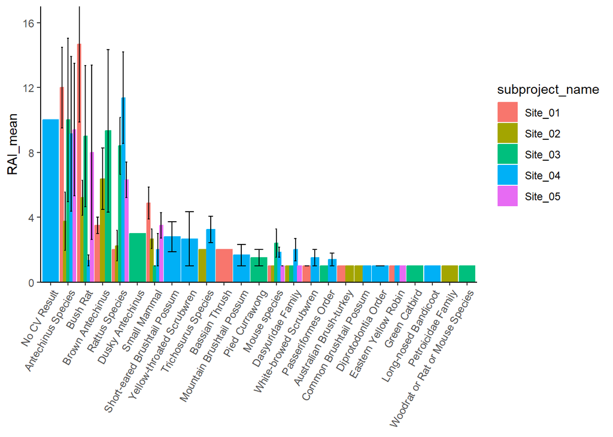

```r
overall.site.means <- species.count.effort %>%
  ggplot(aes(reorder(common_name, -RAI_mean),
             RAI_mean, colour=subproject_name,   fill=subproject_name)) +
  geom_col(position=position_dodge())+
  geom_errorbar(aes(ymin=RAI_mean-RAI_se, ymax=RAI_mean+RAI_se),
                 color="black", width=.5, position = position_dodge(width = 0.9)) +
  theme_classic() +
  theme(axis.text.x = element_text(angle=60, hjust=1), axis.title.x=element_blank()) +
  scale_y_continuous(expand = c(0, 0), limits = c(0,17), oob = rescale_none)

overall.site.means
```

### Plotting the mean number of images per treatment

#### All species/groups

Calculate the mean RAI and SE per treatment:

```r
species.count.treatments <- left_join(species.count, effort, by = "placename") %>%
  mutate(RAI = n/days*3) %>%
  # add treatments
  left_join(treatments, by = "subproject_name") %>%
  group_by(Treatment, common_name) %>%
  summarise_if(is.numeric, list(mean,se)) %>%
  dplyr::select(-days_fn2) %>%
  rename(., c(mean = "n_fn1", days =  "days_fn1", se_mean = "n_fn2",
              RAI_mean = "RAI_fn1", RAI_se = "RAI_fn2"))


glimpse(species.count.treatments)
```

```
Rows: 36
Columns: 7
Groups: Treatment [2]
$ Treatment   <chr> "Older regrowth", "Older regrowth", "Older regrowth", "Old…
$ common_name <chr> "Antechinus Species", "Bush Rat", "Common Brushtail Possum…
$ mean        <dbl> 9.294118, 5.142857, 1.000000, 1.857143, 1.000000, 1.000000…
$ days        <dbl> 3, 3, 3, 3, 3, 3, 3, 3, 3, 3, 3, 3, 3, 3, 3, 3, 3, 3, 3, 3…
$ RAI_mean    <dbl> 9.294118, 5.142857, 1.000000, 1.857143, 1.000000, 1.000000…
$ se_mean     <dbl> 3.0033862, 3.1730155, NA, 0.5947617, 0.0000000, 0.0000000,…
$ RAI_se      <dbl> 3.0033862, 3.1730155, NA, 0.5947617, 0.0000000, 0.0000000,…
```

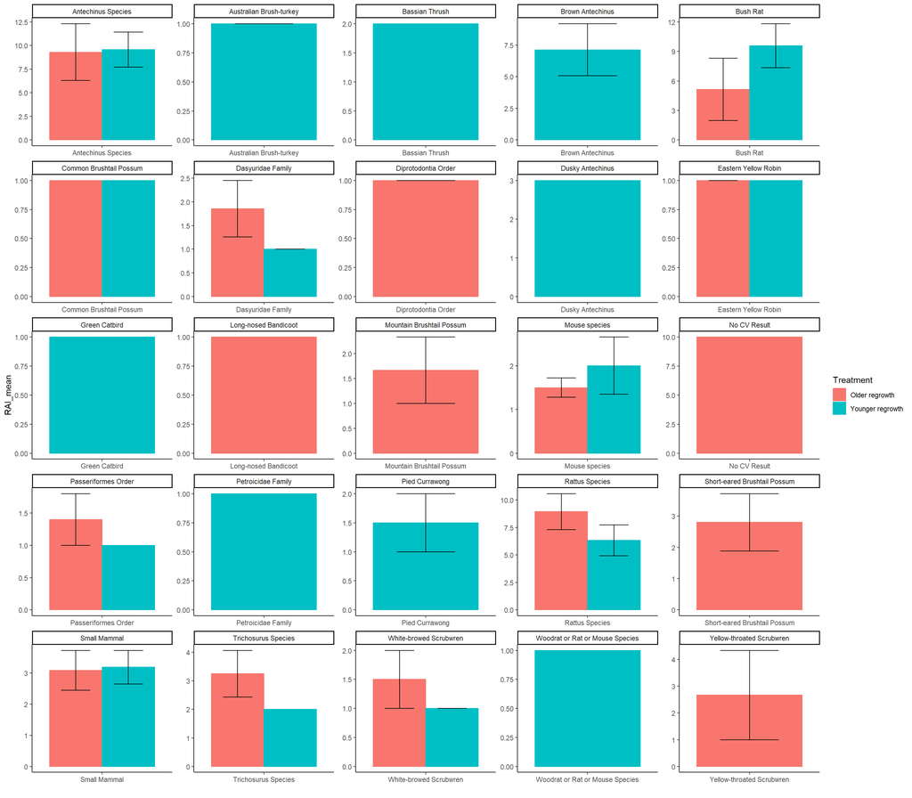

```r
overall.treatment.means <- species.count.treatments %>%
  ggplot(aes(reorder(common_name, -RAI_mean), RAI_mean, colour=Treatment, fill=Treatment)) +          geom_col(position=position_dodge())+
   geom_errorbar(aes(ymin=RAI_mean-RAI_se, ymax=RAI_mean+RAI_se), color="black", width=.5, position = position_dodge(width = 0.9)) +
    theme_classic() +
    facet_wrap(~common_name, scales = "free") +
  xlab("")



overall.treatment.means
```

To save plot out uncomment the below line. Change the filename to your own.:

```r
# ggsave(plot = overall.site.means, "output/BIOL3009_RAI_allSpecies.png", width = 12, height = 7)
```

#### Selecting species to plot

If you want to select different species to plot:

Add of remove species common names to choose what you want to plot.

```r
speciesToPlot <- c("Rattus Species", "Antechinus Species", "Long-nosed Bandicoot", "Common Brushtail Possum")
```

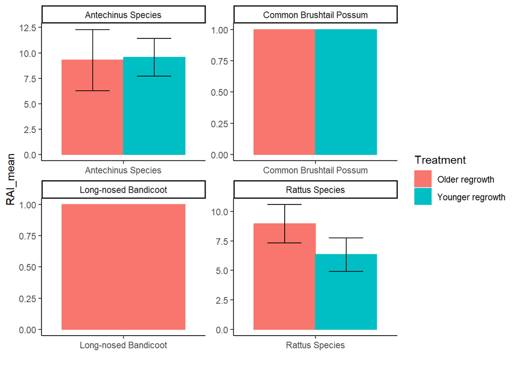

```r
overall.treatment.means.sel <- species.count.treatments %>%
  filter(common_name %in% speciesToPlot) %>%
  ggplot(aes(reorder(common_name, -RAI_mean), RAI_mean, colour=Treatment, fill=Treatment)) +          geom_col(position=position_dodge())+
   geom_errorbar(aes(ymin=RAI_mean-RAI_se, ymax=RAI_mean+RAI_se), color="black", width=.5, position = position_dodge(width = 0.9)) +
    theme_classic() +
    facet_wrap(~common_name, scales = "free") +
  xlab("")

overall.treatment.means.sel
```

To save plot out uncomment the below line

```r
# ggsave(plot = species.site.means , "output/BIOL3009_RAI_Species.png", width = 12, height = 7)
```

### Species richness per treatment, with site as replicate.

Here we will calculate mean species richness per treatment and use each site as a replicate. We will first calculate the number of distinct species per site, then calculate the mean and standard error per treatment.

```r
sp.richness <- species.count %>%
  # Add treatments
  left_join(treatments, by = "subproject_name") %>%
  group_by(Treatment, subproject_name) %>%
  # Count number of distinct species per site
  summarise(n = n_distinct(common_name)) %>%
  rename(., speciesRichness = n) %>%
  # Calculate mean and standard error per treatment
  group_by(Treatment) %>%
  summarise(mean = mean(speciesRichness), se = se(speciesRichness))
```

#### Plotting mean species richness per treatment

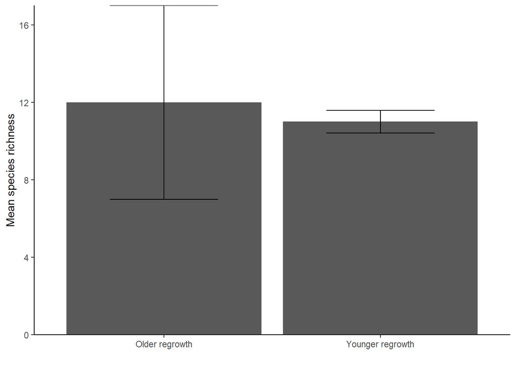

```r
sp.richness.plot <- sp.richness %>%
  ggplot(aes(Treatment, mean)) +
  geom_col(position=position_dodge())+
  geom_errorbar(aes(ymin=mean-se, ymax=mean+se), color="black", width=.5, position = position_dodge(width = 0.9))+
  theme_classic() +
  ylab("Mean species richness") +
  xlab("") +
  scale_y_continuous(expand = c(0, 0))

sp.richness.plot
```

To save plot out uncomment the below line:

```r
# ggsave(plot = sp.richness.plot, "output/BIOL3009_SpeciesRichness.png", width = 12, height = 7)
```

### Species diversity

#### Simpson’s diversity index

Simpson’s diversity index is calculated as:

$$D = 1 - \sum_{i=1}^Np_i^2$$

where $p_i$ is the proportion of species i in the community and $N$ is the number of species.

**Note**

A community with many species, but where one species dominates, will have a lower diversity than a community with fewer species but where they are more evenly distributed.

#### Calculate Simpson’s diversity index

The Simpson index gives more weight to common or dominant species. The index ranges from 0 to 1. We will use the `vegan` package to calculate our diversity indices.

First we need to format the data for the `vegan` package. We will create a wide format data frame with species as columns and sites as rows, with the number of images per species per site as the values. This is similar to the `species.count.effort` data frame we created above, but in a wide format.

```r
library(vegan)

# format data for vegan package
species.count.wide <- records_filter5_min %>%
  group_by(subproject_name, common_name) %>%
  tally() %>%
  ungroup() %>%
  pivot_wider(names_from = common_name, values_from = n, values_fill = 0)
```

Now we can calculate the Simpson’s diversity index for each site. We will group by site and then use the `diversity` function from the `vegan` package to calculate the index.

```r
# calculate Simpson's diversity index per site
Simpson <- species.count.wide %>%
  group_by(subproject_name) %>%
  summarise(across(everything(), sum, na.rm = TRUE)) %>%
  ungroup() %>%
  mutate(Simpson = diversity(select(., -subproject_name), index = "simpson")) %>%
  select(subproject_name, Simpson)

# calc mean Simpson's Diversity index and standard error per treatment

Simpson.mean <- Simpson %>%
  left_join(treatments, by = "subproject_name") %>%
  group_by(Treatment) %>%
  summarise(mean = mean(Simpson), se = se(Simpson))
```

#### Plotting Simpson’s diversity index

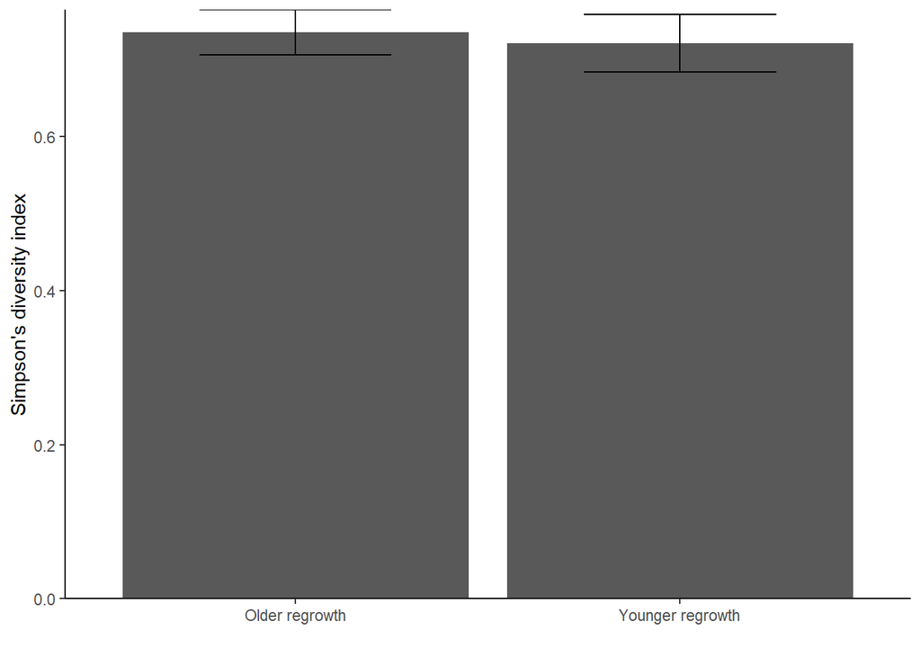

```r
species.diversity.simpson.plot <- Simpson.mean %>%
  ggplot(aes(Treatment, mean)) +
  geom_col(position=position_dodge()) +
  geom_errorbar(aes(ymin=mean-se, ymax=mean+se), color="black", width=.5, position = position_dodge(width = 0.9))+
  theme_classic() + ylab("Simpson's diversity index") + xlab("")+
 scale_y_continuous(expand = c(0, 0))

species.diversity.simpson.plot
```

To save plot out uncomment the below line:

```r
# ggsave(plot = species.diversity.simpson.plot, "output/BIOL3009_SpeciesDiversitySimpson.png", width = 12, height = 7)
```

#### Shannon’s diversity index

Shannon’s diversity index is calculated as:

$$H = -\sum_{i=1}^N p_i ln(p_i)$$

where $p_i$ is the proportion of species $i$ in the community and $N$ is the number of species.

We can calculate this index for each site and take the mean for each treatment and plot the results, as we did above for the Simpson’s index.

```r
# calculate Simpson's diversity index per site
shannon <- species.count.wide %>%
  group_by(subproject_name) %>%
  summarise(across(everything(), sum, na.rm = TRUE)) %>%
  ungroup() %>%
  mutate(Shannon = diversity(select(., -subproject_name), index = "shannon")) %>%
  select(subproject_name, Shannon)

# calc mean Simpson's Diversity index and standard error per treatment

Shannon.mean <- shannon %>%
  left_join(treatments, by = "subproject_name") %>%
  group_by(Treatment) %>%
  summarise(mean = mean(Shannon), se = se(Shannon))
```

#### Plotting Shannon’s diversity index

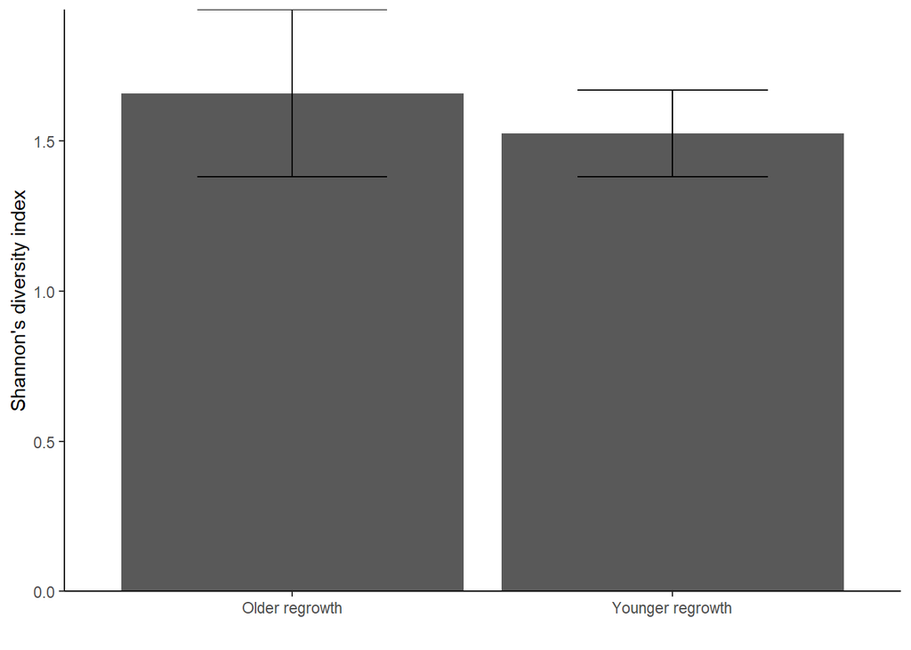

```r
species.diversity.plot <- Shannon.mean %>%
  ggplot(aes(Treatment, mean)) +
  geom_col(position=position_dodge()) +
  geom_errorbar(aes(ymin=mean-se, ymax=mean+se), color="black", width=.5,
                position = position_dodge(width = 0.9)) +
  theme_classic() + ylab("Shannon's diversity index") + xlab("") +
 # theme(axis.text.x = element_text(angle=60, hjust=1), axis.title.x=element_blank()) +
  scale_y_continuous(expand = c(0, 0))

species.diversity.plot
```

To save plot out uncomment the below line:

```r
# ggsave(plot = species.diversity.plot, "output/BIOL3009_SpeciesDiversity.png", width = 12, height = 7)
```

## Task 6 (optional): Detection maps

Detection maps are a useful way to visualise the distribution of species across your study area. They can be used to identify areas of high and low species richness, and to identify areas where certain species are more or less likely to be detected.

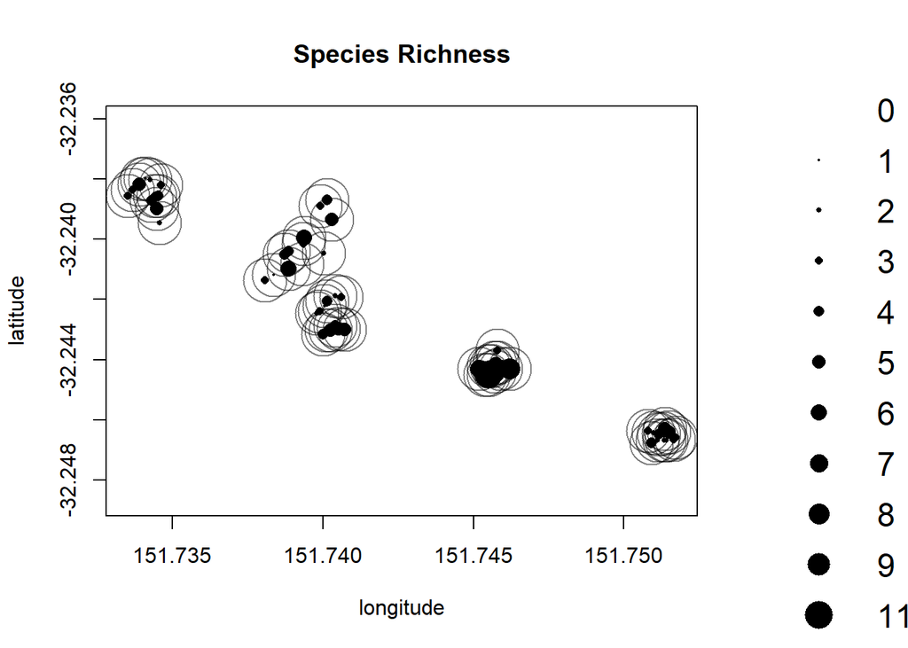

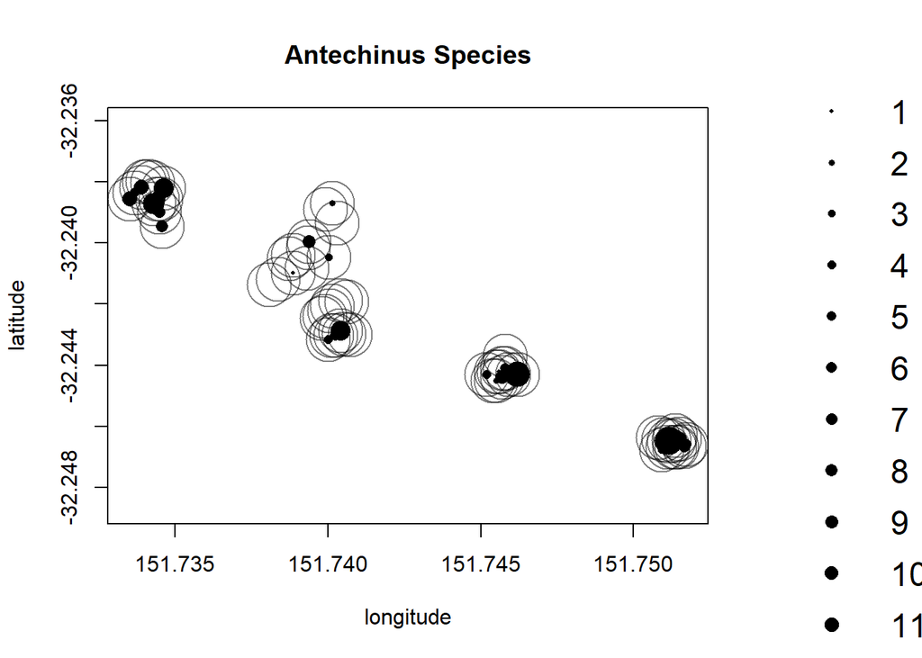

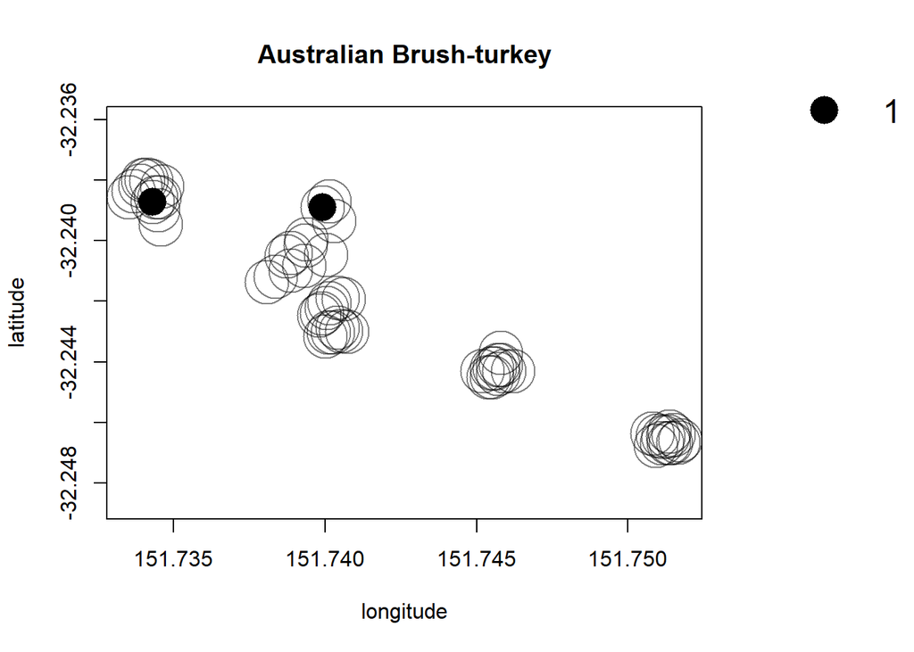

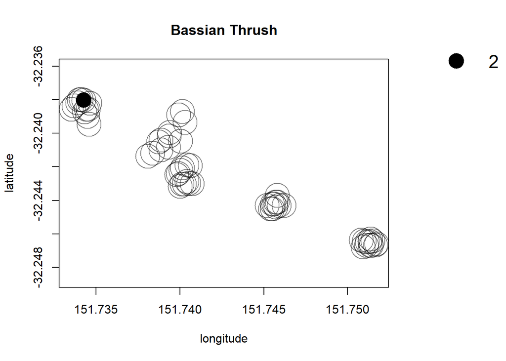

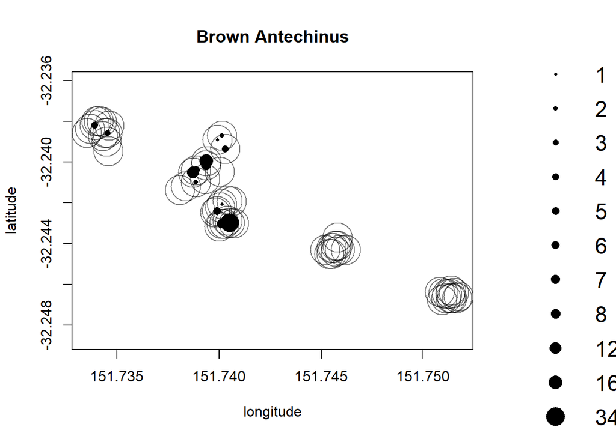

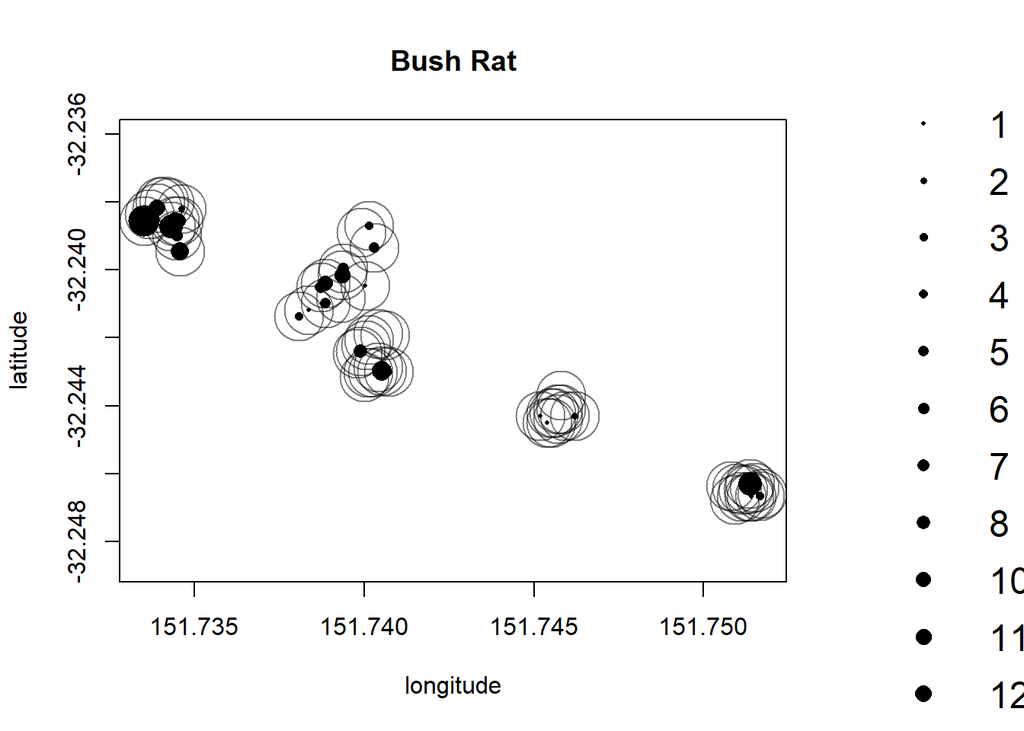

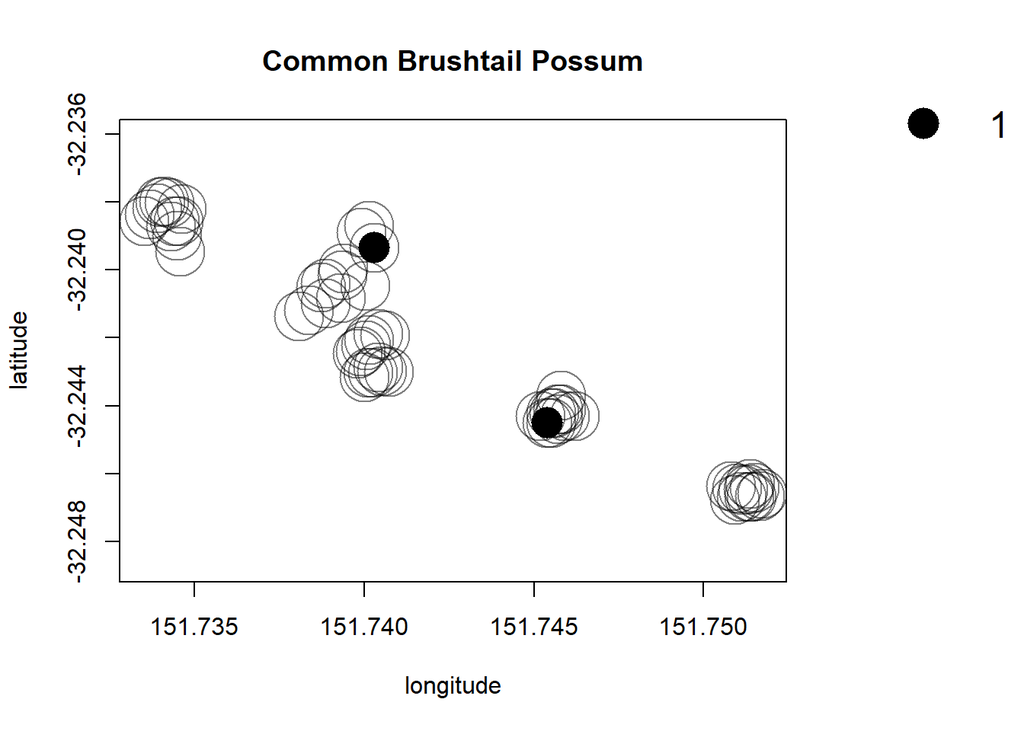

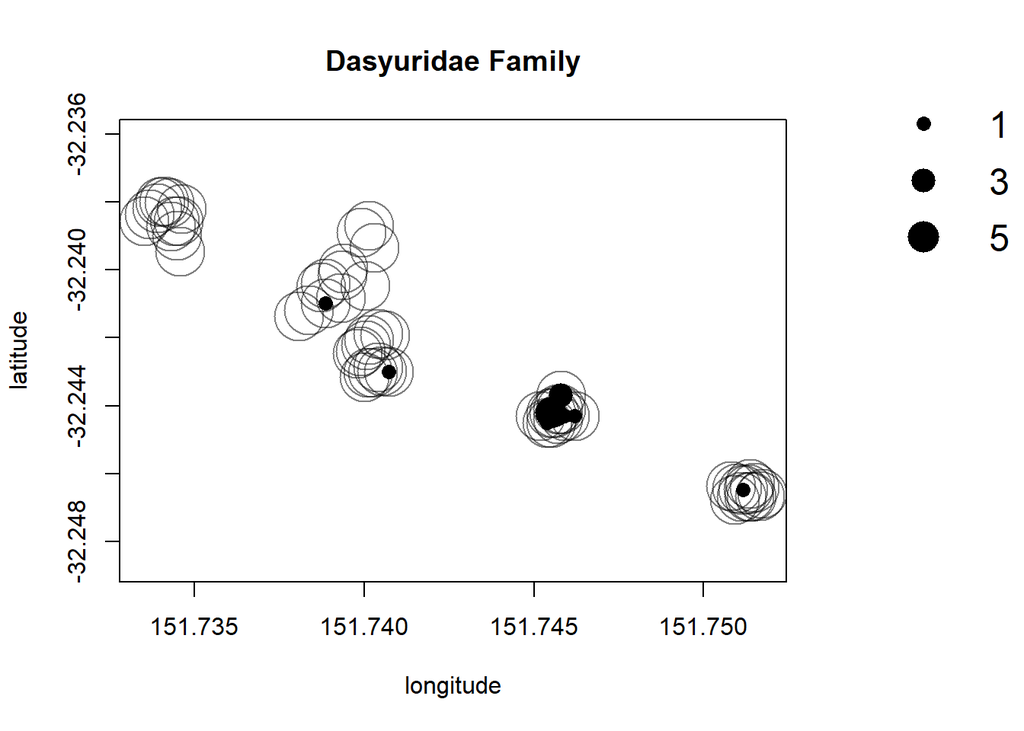

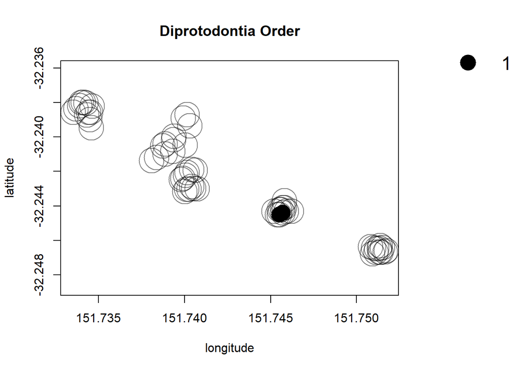

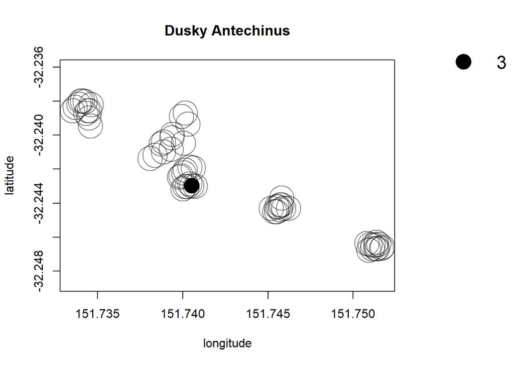

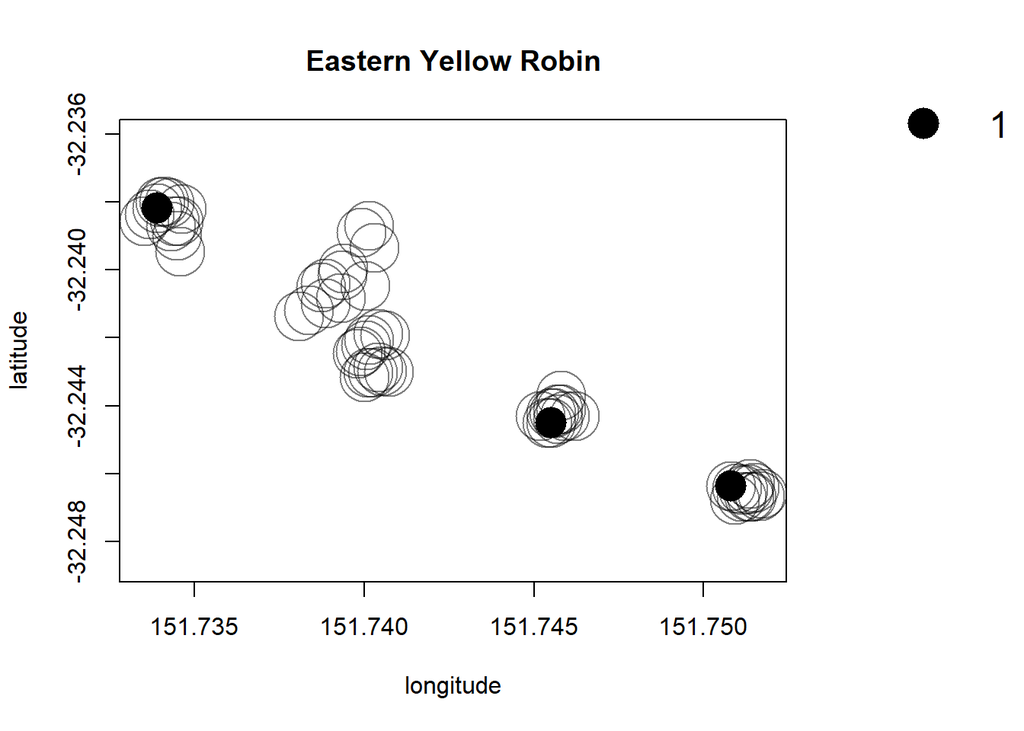

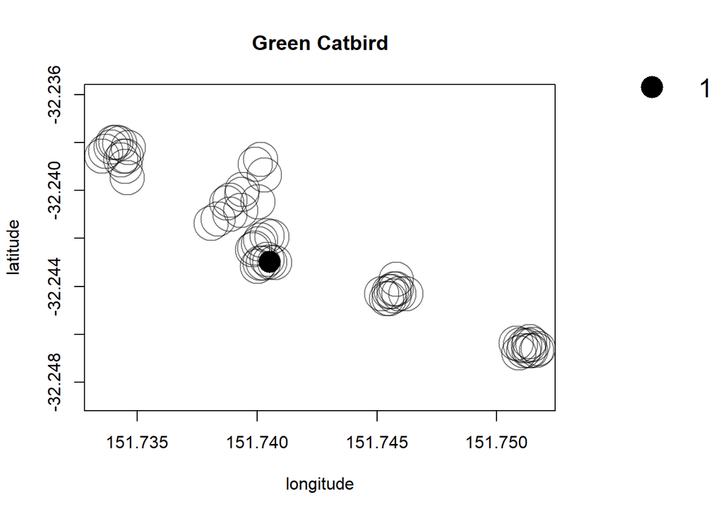

[14 more figures not shown]

```r
detectionMaps(CTtable = Ctable.WI,
              recordTable = records_filter5_min,
              Xcol = "longitude",
              Ycol = "latitude",
              #speciesToShow = "Swamp Wallaby",
              stationCol = "placename",
              speciesCol = "common_name",
              writePNG = FALSE,
              plotR = TRUE,
              printLabels = FALSE,
              richnessPlot = TRUE,
              addLegend = TRUE,
              writeShapefile = FALSE,
              speciesPlots = TRUE,
              shapefileName = "BIOL3009_Species_2023", # change filename to current year
              shapefileDirectory = "output/",
              shapefileProjection ="+proj=longlat +ellps=GRS80 +towgs84=0,0,0,0,0,0,0 +no_defs" )
```

## Task 7 (optional): Diel activity

### Species list

```r
unique(records_filter5_min$common_name)
```

```
 [1] "Antechinus Species"              "Bush Rat"
 [3] "Small Mammal"                    "Brown Antechinus"
 [5] "Australian Brush-turkey"         "Mouse species"
 [7] "Rattus Species"                  "White-browed Scrubwren"
 [9] "Eastern Yellow Robin"            "Bassian Thrush"
[11] "Dasyuridae Family"               "Petroicidae Family"
[13] "Common Brushtail Possum"         "Trichosurus Species"
[15] "Dusky Antechinus"                "Green Catbird"
[17] "Pied Currawong"                  "Passeriformes Order"
[19] "Woodrat or Rat or Mouse Species" "Short-eared Brushtail Possum"
[21] "Mountain Brushtail Possum"       "Long-nosed Bandicoot"
[23] "No CV Result"                    "Yellow-throated Scrubwren"
[25] "Diprotodontia Order"
```

### Diel activity plots

Change the species names to match your data set and the species you want to plot.

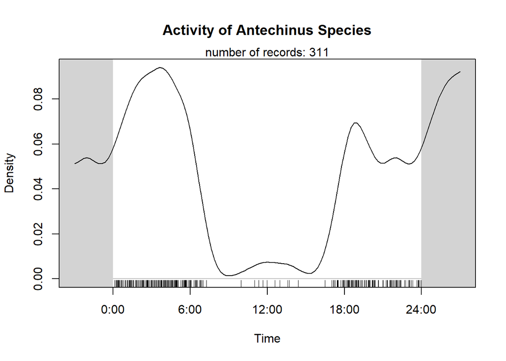

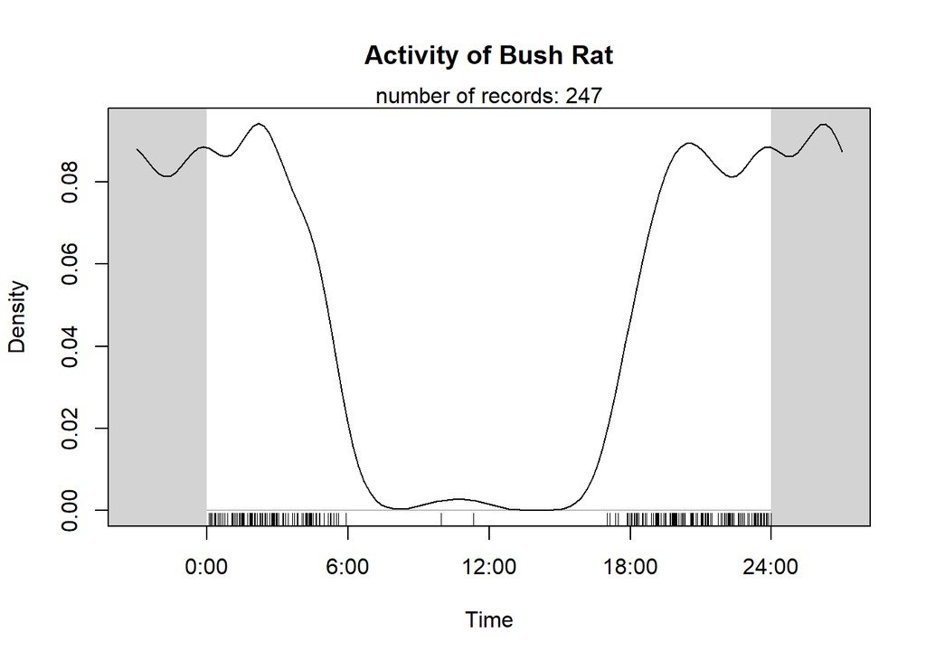

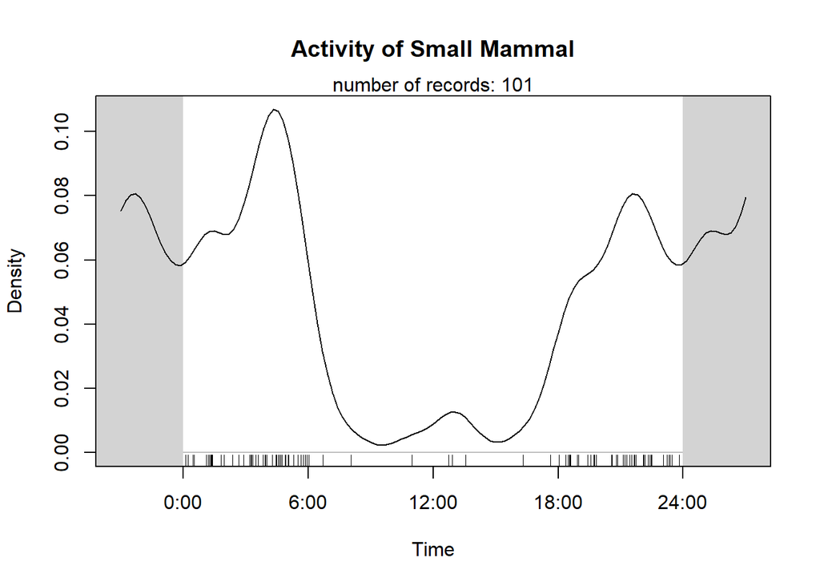

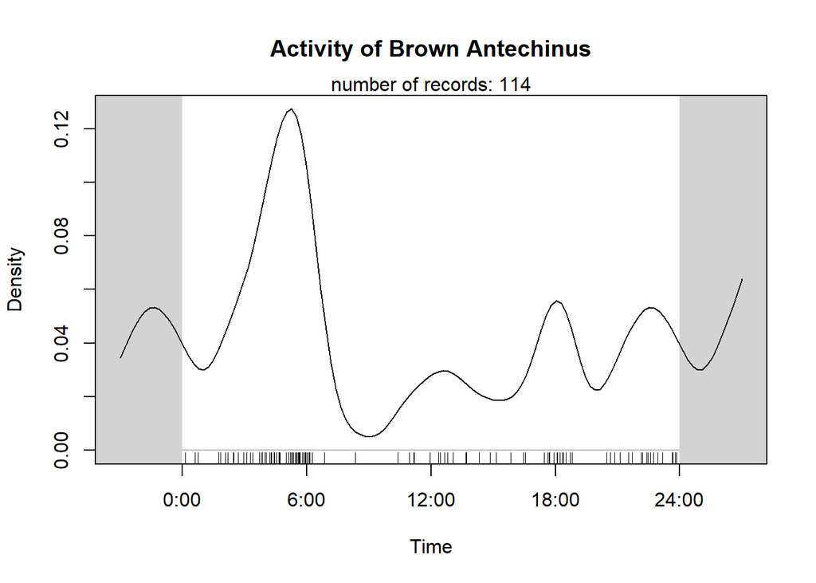

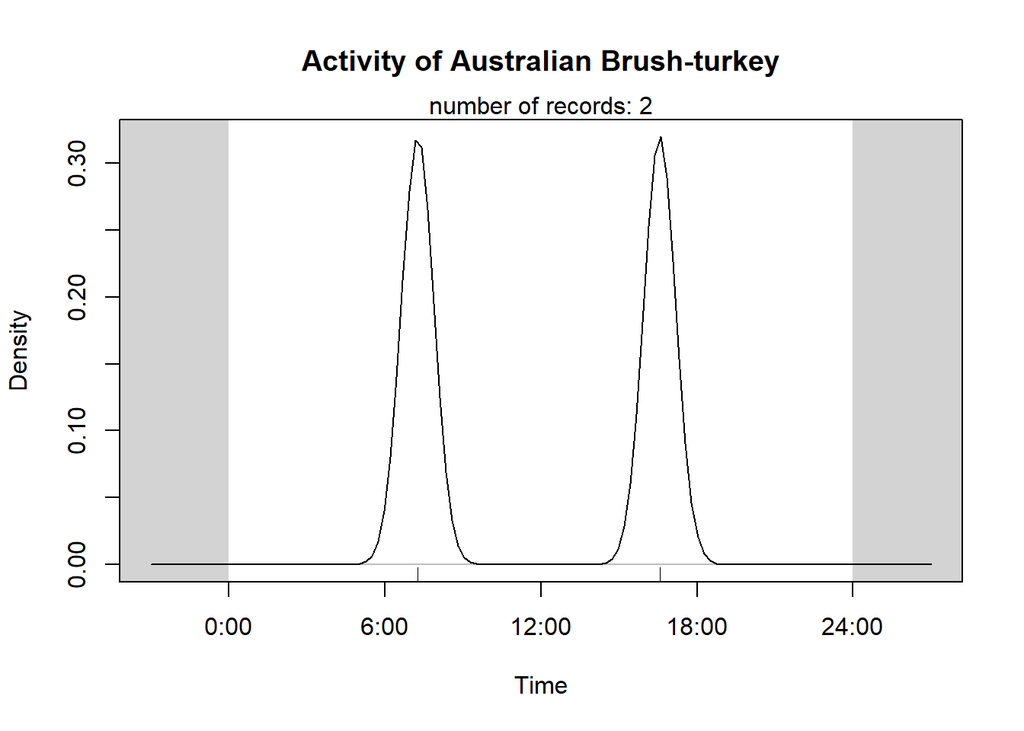

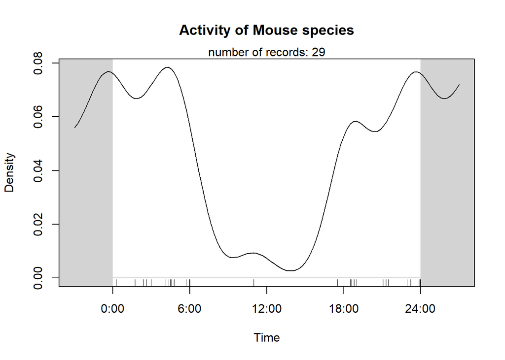

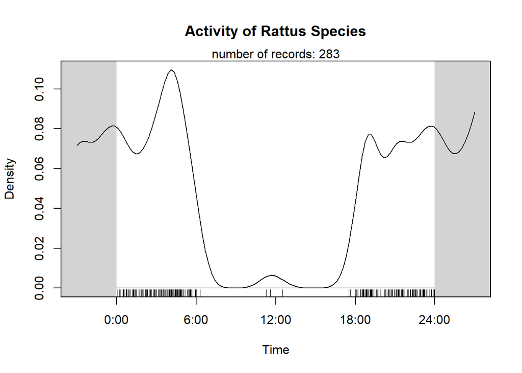

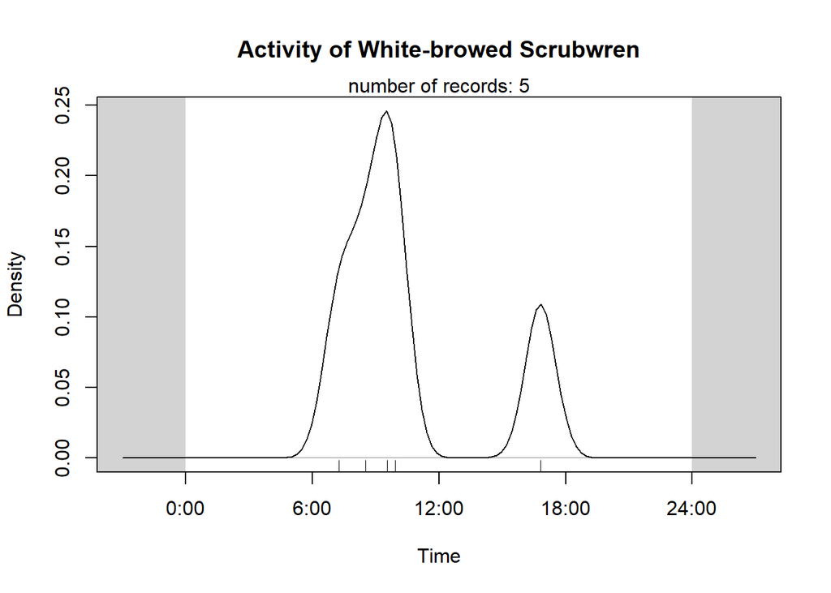

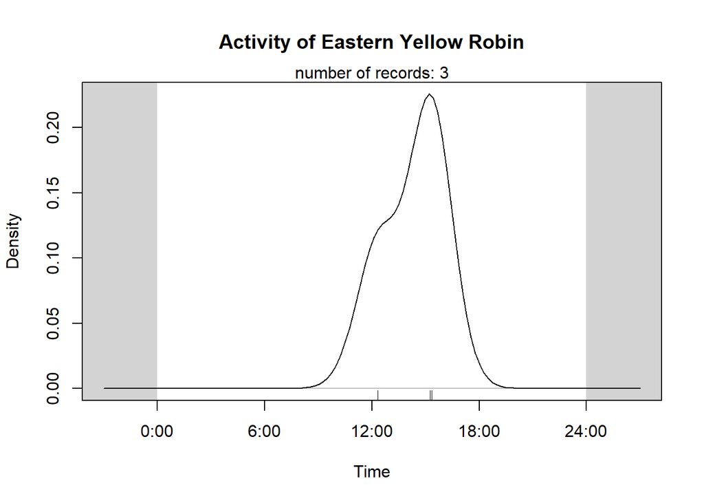

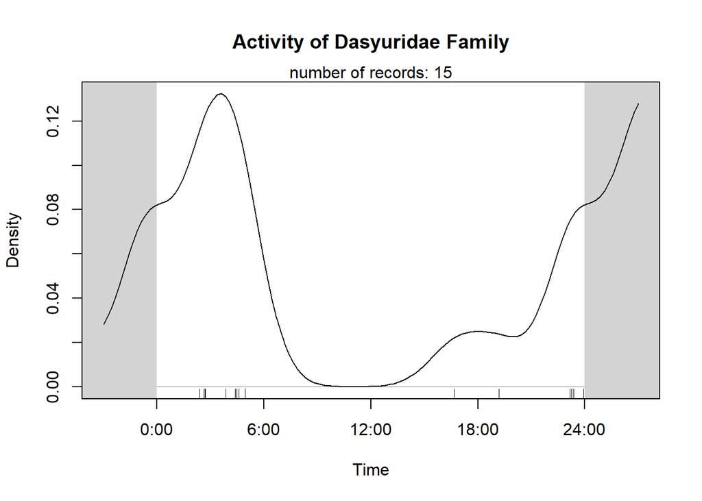

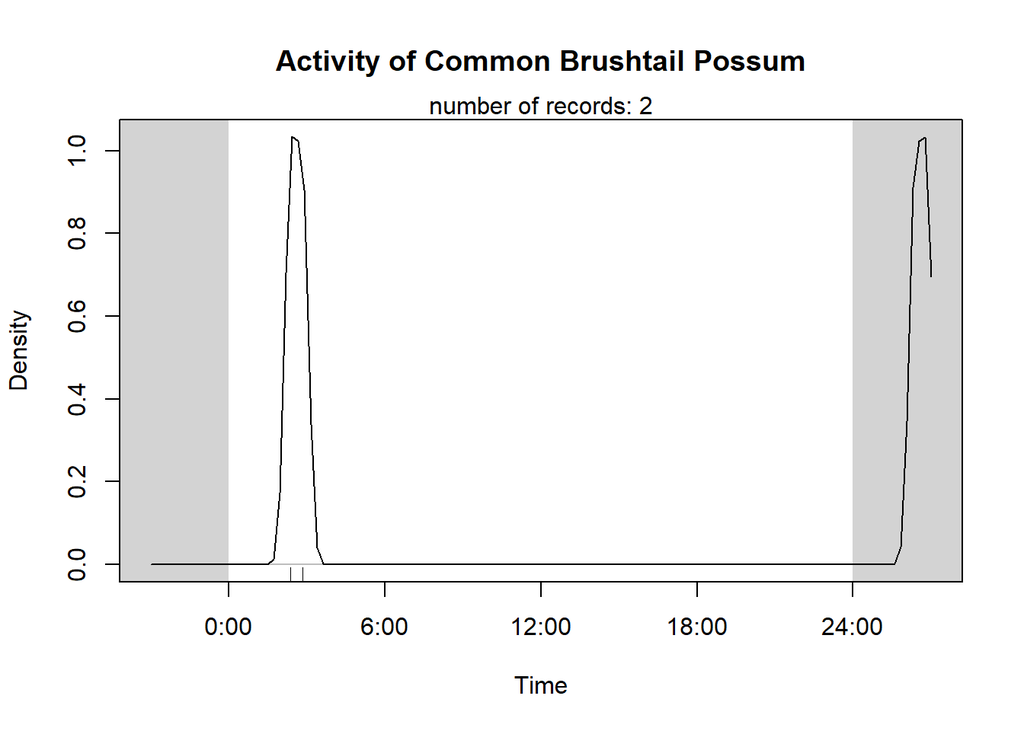

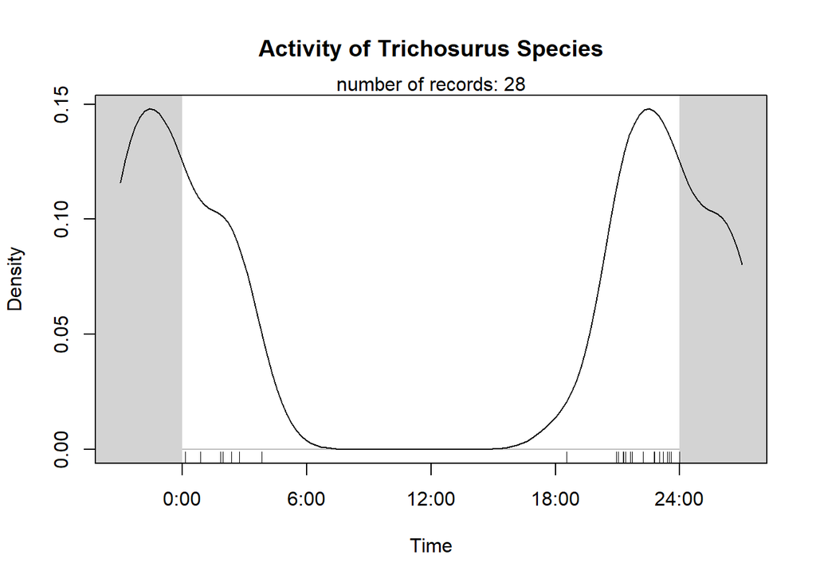

[8 more figures not shown]

```r
activityDensity(recordTable = records_filter5_min,
                speciesCol = "common_name",
                allSpecies = TRUE,
                writePNG = FALSE,
                plotDirectory = "output/",
                plotR = TRUE,
                recordDateTimeCol = "DateTimeOriginal",
                recordDateTimeFormat = "ymd HMS",
                add.rug = TRUE)
```